# ClassSchedule

Xijia Luo

9/17/2019

# Class Schedule

### PSU 016: First-Year Seminar

For some reason I admit that I was a little surprised to find a Wikipedia page about first-year seminar classes at American Universities, but [here’s the link](https://en.wikipedia.org/wiki/The_First_Year_Experience_Program)! The page doesn’t currently have a picture, so a classic Penn State picture of Old Main seems as fitting as anything else.

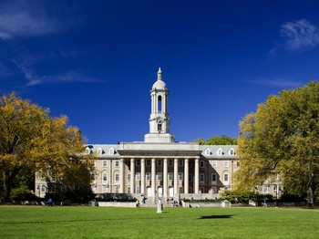

### STAT 184:Introduction to R programming

Stat184 is a compulsory course for all statistics majors students in psu. This class is also a prerequesite class of STAT380 which is another compulsory course for all statistics majors students in psu. I applied for double major in stat last semester so that I have to take this course.

A link to class: https://mdbeckman.github.io/PSU-STAT-184/

[figure not shown]

### STAT 461: Anly of Variance

As a stat major student, I need several 400level stat course. Since I have already take stat462 and stat463, I would like to take stat461 as well. These three courses are related to Rstudio which I think that will really help me in my future job experience.

A link to class: https://onlinecourses.science.psu.edu/statprogram/stat461

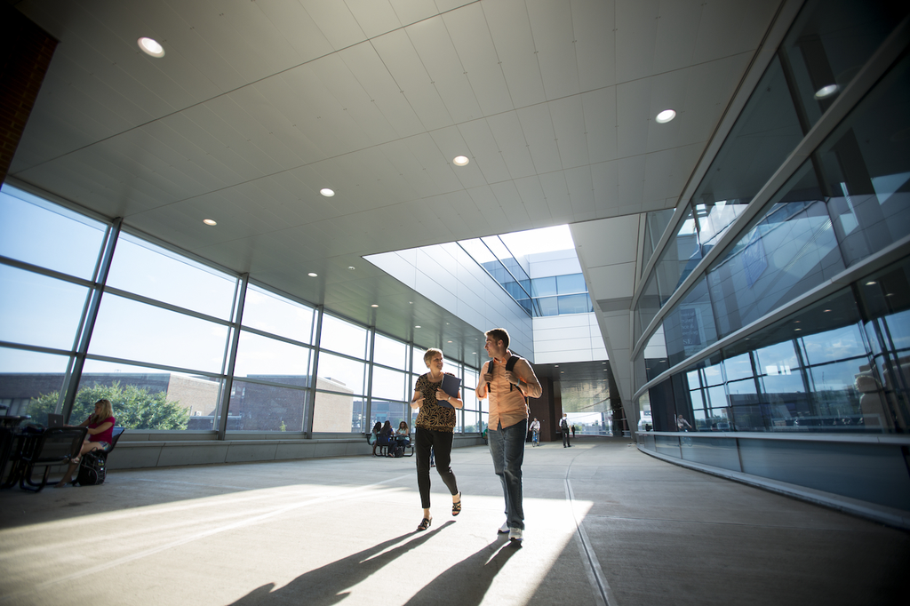

### Econ 304: Inmd Macroec Analysis

A appliance stat major student also require another major or minor besides math. I have already taken econ102&106 through ap exam before i came to PSU and I only need to take econ302&304 andextra two 400level econ courses in order to get a econ minor. Thus, I choose to have a econ minor. Econ304 is thecompulsory course for econ minor students.

A link to class: http://www.personal.psu.edu/rxc122/econ304.htm

[figure not shown]